# Production

August 29, 2018

## Pregame

- Sapling is not working for multiple classes and students - I will postpone homework for a week, but that means two homeworks will be due next Friday at 5pm.

## Feedback

### Good:

- I enjoyed the videos as visual interpreting the new information being taught.
- I liked thinking about how people typically make irrational choices rather than making perfect rational choices all the time.

### Needs improvement:

- Please go slower and take more time explaining concepts used in class, beginning with vocab, and then how it applies to real world scenarios.
- Finishing each lesson in class, so when you do the knowledge check we got it.

## Questions? Critiques?

## Production

“The production of too many useful things results in too many useless people.” – Karl Marx

## Production Questions

- How can we describe the way things are made generally?
- What different kinds of resources are needed to produce goods?
- How do different resources behave differently?

## Production functions

- **Production function** - *a function that describes the quantity of output generated from a given amount of inputs.*

E.g.: What does it take to produce coffee?

- coffee beans
- baristas, managers
- equipment (grinder, espresso machine, refrigerator)
- a building
- power
- etc…

All of these are inputs!

## Types of inputs

- **Fixed input** - *An input that can’t be changed in the short run.*
- **Variable input** - *An input that can vary easily at any time.*
- **But**: All inputs are variable in the **long run**.

## Long run and short run

From Krugman and Wells:

- The **long run** is the period in which all inputs can be varied.
- The **short run** is the period in which at least one input is fixed.

E.g: Buildings are **fixed** in the **short term**, but you can expand or buy more buildings in the **long term**, so they are variable in the **long term**.

## Total Product

- **Total Product Curve** - *Shows quantity produced as the quantity of a variable input changes.*

Imagine you have only one cash register and one espresso machine…

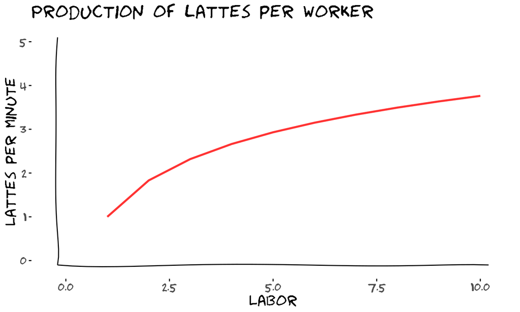

## Whaaaaa?

[interactive chart not shown]

[via GIPHY](https://giphy.com/gifs/are-you-serious-insane-Ni4cpi0uUkd6U)

## An example with numbers

| Labor | Lattes | Marginal Production |
| --- | --- | --- |
| 1 | 1 | 1 |
| 2 | 1.832 | 0.8318 |
| 3 | 2.318 | 0.4866 |
| 4 | 2.664 | 0.3452 |
| 5 | 2.931 | 0.2678 |
| 6 | 3.15 | 0.2188 |
| 7 | 3.335 | 0.185 |
| 8 | 3.495 | 0.1602 |
| 9 | 3.637 | 0.1413 |
| 10 | 3.763 | 0.1264 |

## An example plotted

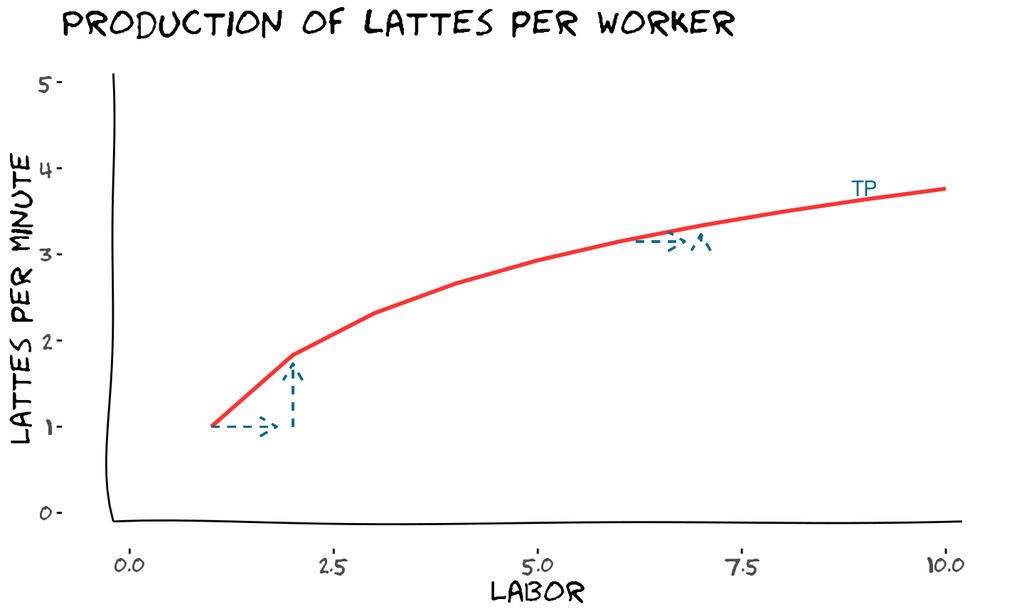

## Marginality again?!?

[figure not shown]

## Marginal production

- **Marginal product** - *the additional output produced from one additional unit of input.*

\[\mbox{MP} = \frac{\Delta Q}{ \Delta X} = \frac{Q_{new} - Q_{old}}{ X_{new} - X_{old}}\]

In particular:

- **Marginal product of labor** - *the additional output produced from one additional worker.*
- **Marginal product of capital** - *the additional output produced from one additional unit of capital.*

\[\mbox{MPL} = \frac{\Delta Q}{ \Delta L} = \frac{Q_{new} - Q_{old}}{ L_{new} - L_{old}}, \; \; \mbox{MPK} = \frac{\Delta Q}{ \Delta K} = \frac{Q_{new} - Q_{old}}{ K_{new} - K_{old}}\]

## Diminishing returns

- **Diminishing returns** - *Each additional increase in an input leads to a correspondingly smaller increase in output (i.e. the curve is shaped down).*

## Increasing fixed inputs

*What impact would increasing fixed costs have on production?*

## Increasing fixed inputs

- Increased fixed inputs make variable inputs like labor more productive.

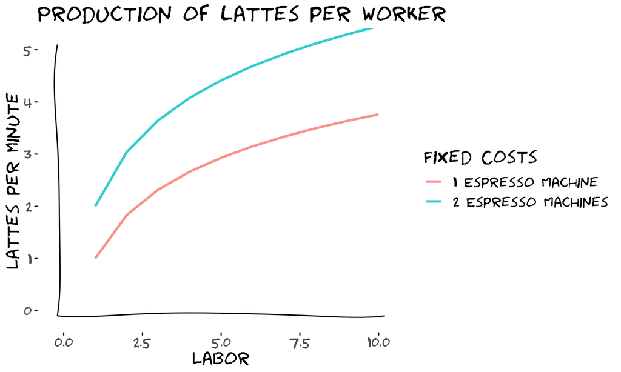

## Increased fixed inputs

[video not shown]

## Does automation lead to less employment?

**This is an open question in economics.**

A debate:

*Wayde*: Increasing capital replaces workers with robots, so those jobs are lost, QED.

*Paul*: It’s true that robots replace workers, but they also create more jobs through robot maintenance, robot development, and open up whole new industries like software development.

*Wayde*: But those new jobs aren’t as numerous as the original jobs, and they require more skilled labor, so less educated and less skilled people are worse off than before.

*Paul*: We can retrain those workers to work in higher skilled areas. Not to mention, automation makes everyone better off because things are cheaper, so even people who are paid less benefit because their food costs less when it’s production is automated.

etc…

## One cent hamburgers

[video not shown]

## Definitions

- **Fixed input** - *An input that can’t be changed in the short run.*
- **Variable input** - *An input that can vary easily at any time.*
- **Total Product Curve** - *Shows quantity produced as the quantity of a variable input changes.*
- **Marginal product** - *the additional output produced from one additional unit of input.*
- **Marginal product of labor** - *the additional output produced from one additional worker.*
- **Marginal product of capital** - *the additional output produced from one additional unit of capital.*
- **Diminishing returns** - *Each additional increase in an input leads to a correspondingly smaller increase in output (i.e. the curve is shaped down).*

## Wrapping Up

- Complete the [knowledge check](https://goo.gl/forms/GF32BOHRlCyEHr4Z2) for today’s participation point.
- Please provide [feedback](https://goo.gl/forms/8SiOwdi19kN8cINJ3) on today’s lecture.